# chapter 9 In-Class

Chapter 9 - Time series

```r
library("Ecdat")
library("fGarch")
library("evir")
library("forecast")
data(CRSPday, package="Ecdat")
data(bmw)
summary(bmw)
```

```
      Min.    1st Qu.     Median       Mean    3rd Qu.
-0.1406000 -0.0066560  0.0000000  0.0003407  0.0071260
      Max.
 0.1172000
```

```r
length(bmw)
```

```
[1] 6146
```

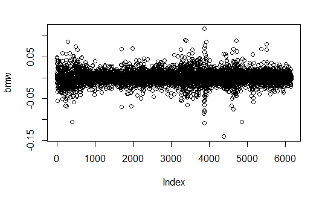

```r
plot(bmw)
```

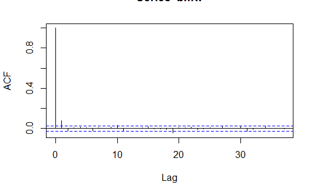

```r
acf(bmw)
```

```r
Box.test(x=bmw, lag=5, type="Ljung-Box")
```

```
    Box-Ljung test

data:  bmw
X-squared = 44.987, df = 5, p-value = 1.46e-08
```

The test gives a very small p-value, so I could reject the null hypothesis that the data is indipendenly distributed. There is serial correlation within the data.

So now

```r
fitAR1 = arima(bmw, order = c(1,0,0))
# here I fit AR(1)
fitAR1
```

```
Call:
arima(x = bmw, order = c(1, 0, 0))

Coefficients:
         ar1  intercept
      0.0811      3e-04
s.e.  0.0127      2e-04

sigma^2 estimated as 0.0002163:  log likelihood = 17212.34,  aic = -34418.68
```

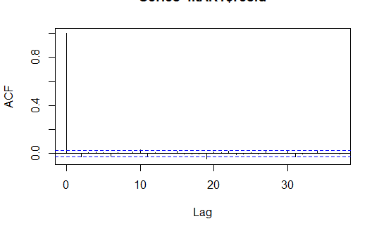

```r
acf(fitAR1$resid)
```

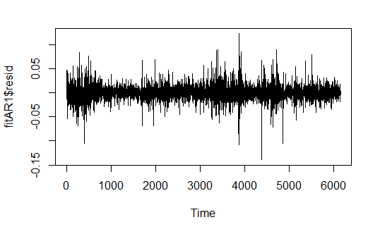

```r
plot(fitAR1$resid)
```

```r
Box.test(fitAR1$resid,lag=5,type="Ljung-Box",fitdf=1)
```

```
    Box-Ljung test

data:  fitAR1$resid
X-squared = 6.8669, df = 4, p-value = 0.1431
```

ACF graph goes quickly to zero, it should indicate stationarity. The Box test has a large p-value, which leads to fail to reject the null hypothesis that the residulals are uncorrelated, at least small lags. So, AR(1) provides a quite adequate fit here. Notice that we use AR(1)’s residuals to test to see if there is any autocorrelation left.

```r
data(Mishkin)
summary(Mishkin)
```

```
      pai1             pai3             tb1
 Min.   :-7.565   Min.   :-3.794   Min.   : 0.3215
 1st Qu.: 1.364   1st Qu.: 1.660   1st Qu.: 2.5395
 Median : 3.589   Median : 3.679   Median : 4.5711
 Mean   : 4.006   Mean   : 4.018   Mean   : 4.9983
 3rd Qu.: 6.118   3rd Qu.: 5.609   3rd Qu.: 6.8348
 Max.   :19.570   Max.   :16.431   Max.   :15.7906
      tb3               cpi
 Min.   : 0.5748   Min.   : 23.50
 1st Qu.: 2.8821   1st Qu.: 29.50
 Median : 5.0470   Median : 39.00
 Mean   : 5.4098   Mean   : 55.95
 3rd Qu.: 7.4577   3rd Qu.: 84.40
 Max.   :16.0278   Max.   :133.80
```

```r
?Mishkin
```

The first one is one-month inflation rate (in percent, annual rate).

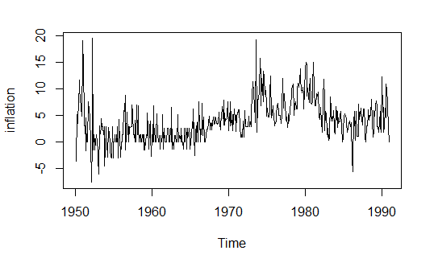

```r
inflation = Mishkin[,1]
plot(inflation)
```

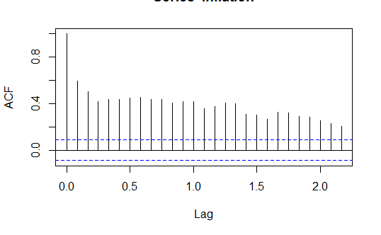

```r
# it doesn't seem stationary
acf(inflation)
```

```r
# The ACF decays to zero slowly, showing that this is a sign of either nonstationarity or possibly of stationarity with long-memory dependence.
```

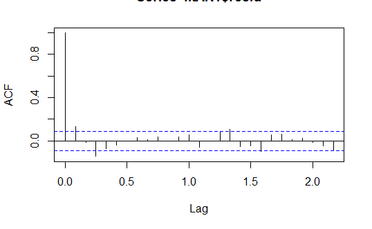

```r
fitAR1= arima(inflation, order=c(1,0,1))
acf(fitAR1$resid)
```

```r
Box.test(fitAR1$resid, lag=5, type="Ljung-Box", fitdf=1)
```

```
    Box-Ljung test

data:  fitAR1$resid
X-squared = 22.491, df = 4, p-value = 0.00016
```

Low p-value show a significant autocorrelation within the past 4 lags.

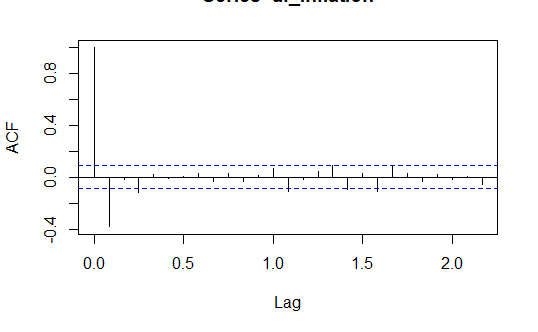

```r
library(timeSeries)
df_inflation = diff(inflation)
?diff
acf(df_inflation) # quicky decaying to zero, quite stationary I assume
```

```r
fitART=arima(df_inflation, order=c(1,0,0))
fitAR1
```

```
Call:
arima(x = inflation, order = c(1, 0, 1))

Coefficients:
         ar1      ma1  intercept
      0.9628  -0.7402     4.0090
s.e.  0.0182   0.0575     0.8936

sigma^2 estimated as 8.741:  log likelihood = -1229.41,  aic = 2466.83
```